# Preliminary Data Exploration

## Introduction

This R Markdown document details the steps of preliminary exploratory analysis conducted on the MAARS dataset for preparing for the analysis to determine the connections between atopic dermititis lesioned and non-lesioned skin samples.

## Preparation

Load libraries, load data, and prepare the data.

```r
# load libraries
#library(rstudioapi)
library(ggplot2)
library(dplyr)
library(qdapTools)
library(kableExtra)

# set working directory
#setwd(dirname(rstudioapi::getSourceEditorContext()$path))
setwd("/Users/thewooz/Documents/Omics-Project")

# load the data
all_data<- read.csv("/Users/thewooz/Documents/Omics-Project/filter-data/all.csv")
ad_full<-  read.csv("/Users/thewooz/Documents/Omics-Project/filter-data/ad_full.csv")

# order the clinical groups
all_data$clinical_group<- factor(all_data$clinical_group, levels=c("AD","PSO","CTRL"))

# rename the factors for lesional/non-lesional
levels(all_data$lesional) <- c("Lesional","Non-Lesional")

# reduce the all_data file to include just the AD samples
ad_data<- subset(all_data, all_data$clinical_group == 'AD')
```

## Describe the Samples

Counts of lesional vs. non-lesional samples among each of the clinical groups.

```r
# table of percent of SAMPLES per clinical group and lesional/non-lesional
clingroup<- round(prop.table(table(all_data$clinical_group, all_data$lesional))*100,2)
clingroup %>% kable(caption = "Percent of Lesional Samples per Clinical Group") %>% kable_styling(bootstrap_options = "striped", full_width = F)
```

Percent of Lesional Samples per Clinical Group

|  | Lesional | Non-Lesional |
| --- | --- | --- |
| AD | 13.43 | 13.11 |
| PSO | 19.42 | 19.58 |
| CTRL | 0.00 | 34.47 |

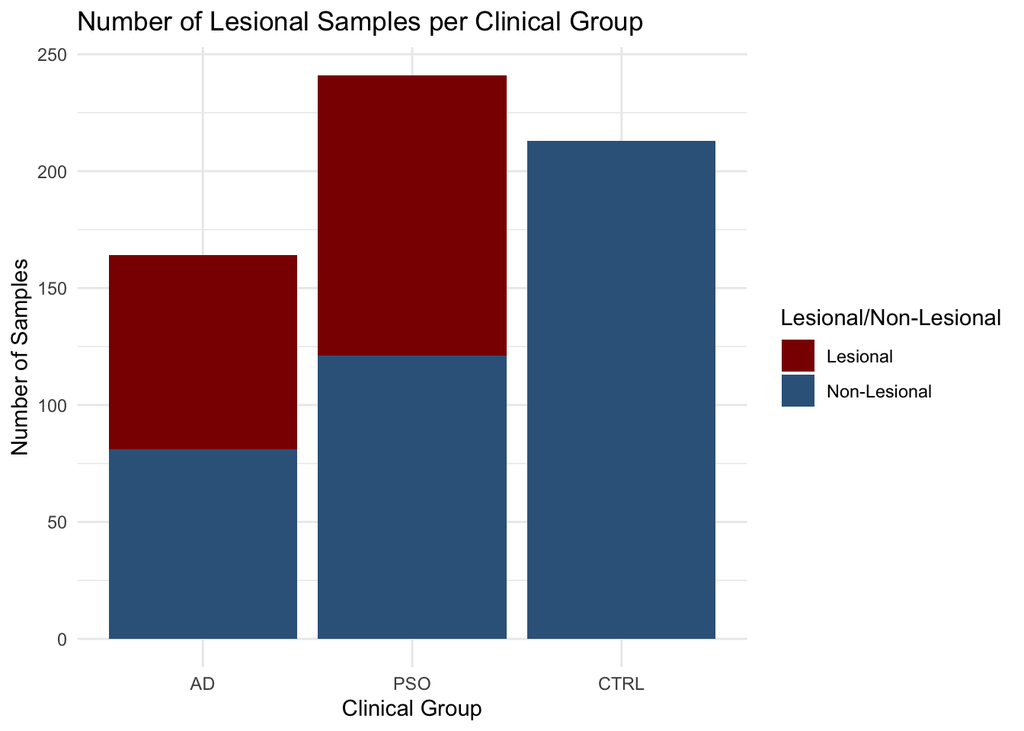

```r
# bar chart for SAMPLES per clinical group and lesional/non-lesionsl
ggplot2::ggplot(data=all_data, aes(clinical_group, fill=lesional))+
  geom_bar(stat="count", position="stack")+
  scale_fill_manual(values=c("red4","steelblue4"),name="Lesional/Non-Lesional", labels=c("Lesional","Non-Lesional"))+
  theme_minimal()+
  xlab("Clinical Group")+
  ylab("Number of Samples")+
  ggtitle("Number of Lesional Samples per Clinical Group")
```

## Describe the Participants

Create a dataset of unique participants and describe their characteristics

```r
# create dataset of unique participants
reduce<- all_data[ ,c(6,2,7:34)]
undup_pts<- reduce[!duplicated(reduce$MAARS_identifier), ]

# report up to 4 digits
options(digits=4)

# gender (percent)
gender<-
  undup_pts %>%
  group_by(clinical_group, Gender) %>%
  summarise(n = n()) %>%
  mutate(RelativeFrequency = paste0(round(100 * n/sum(n), 2), "%"))
gender %>% kable(caption = "Gender (AD Group)") %>% kable_styling(bootstrap_options = "striped", full_width = F)
```

Gender (AD Group)

| clinical_group | Gender | n | RelativeFrequency |
| --- | --- | --- | --- |
| AD | Female | 38 | 44.19% |
| AD | Male | 48 | 55.81% |
| PSO | Female | 27 | 21.43% |
| PSO | Male | 99 | 78.57% |
| CTRL | Female | 72 | 63.72% |
| CTRL | Male | 41 | 36.28% |

```r
# age (min, max, mean, SD)
age<-
  undup_pts %>%
  group_by(clinical_group) %>%
  summarize(Min=min(CUSTOM_Age, na.rm=TRUE),
            Max=max(CUSTOM_Age, na.rm=TRUE),
            Mean=mean(CUSTOM_Age, na.rm=TRUE),
            SD=sd(CUSTOM_Age, na.rm=TRUE))
age %>% kable(caption = "Age (AD Group)") %>% kable_styling(bootstrap_options = "striped", full_width = F)
```

Age (AD Group)

| clinical_group | Min | Max | Mean | SD |
| --- | --- | --- | --- | --- |
| AD | 20 | 83 | 43.86 | 14.57 |
| PSO | 20 | 77 | 48.67 | 13.51 |
| CTRL | 19 | 77 | 35.15 | 13.62 |

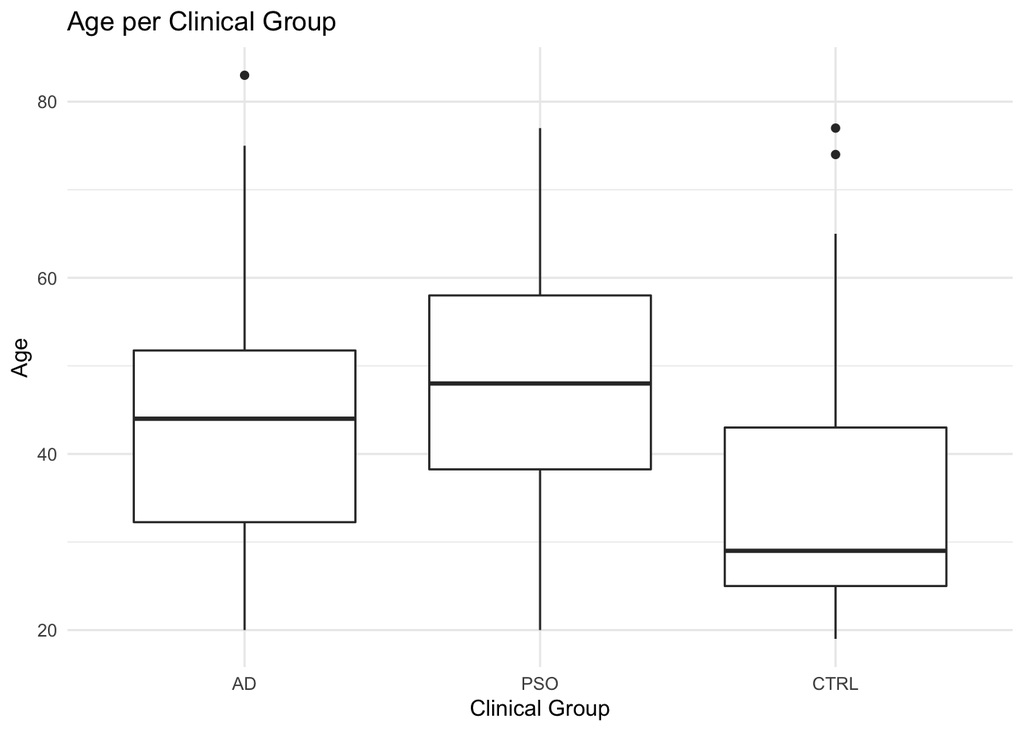

```r
# boxplot for age
ggplot2::ggplot(data=undup_pts, aes(x=clinical_group, y=CUSTOM_Age))+
  geom_boxplot()+
  theme_minimal()+
  xlab("Clinical Group")+
  ylab("Age")+
  ggtitle("Age per Clinical Group")
```

## Clinical Characteristics of the AD Group

```r
# create dataframe of unique AD patients
undup_AD<- undup_pts[which(undup_pts$clinical_group=='AD'), ]

# number/percent of AD patients with each type of allergy
allergies<- (mtabulate(undup_AD[grep('Allergies',names(undup_AD), value=T)]))
allergies$Percent<- allergies[,2]/allergies[,1]+allergies[,2]
row.names(allergies)<- c("Psuedo Drug","Dust Mite","Food","Pollen","Contact", "Drug","Animal")
p_allergies<-allergies[ ,2:3]
colnames(p_allergies)[colnames(p_allergies)=="True"]<- "n"
p_allergies %>% kable(caption = "Allergies (AD Group)") %>% kable_styling(bootstrap_options = "striped", full_width = F)
```

Allergies (AD Group)

|  | n | Percent |
| --- | --- | --- |
| Psuedo Drug | 2 | 2.024 |
| Dust Mite | 15 | 15.211 |
| Food | 37 | 37.755 |
| Pollen | 47 | 48.205 |
| Contact | 14 | 14.194 |
| Drug | 7 | 7.089 |
| Animal | 33 | 33.623 |

```r
# number/percent of AD patients taking each type of medication
meds<- (mtabulate(undup_AD[grep('Medication',names(undup_AD), value=T)]))
meds$percent<- meds[,2]/meds[,1]+meds[,2]
row.names(meds)<- c("Anti-Hypertensive","Anti-Inflammatory","Other Hormones","Thyroid Hormones","Statins", "Insulin","Other")
p_meds<- meds[ ,2:3]
colnames(p_meds)[colnames(p_meds)=="True"]<- "n"
p_meds %>% kable(caption = "Medications (AD Group)") %>% kable_styling(bootstrap_options = "striped", full_width = F)
```

Medications (AD Group)

|  | n | percent |
| --- | --- | --- |
| Anti-Hypertensive | 14 | 14.194 |
| Anti-Inflammatory | 8 | 8.103 |
| Other Hormones | 6 | 6.075 |
| Thyroid Hormones | 4 | 4.049 |
| Statins | 7 | 7.089 |
| Insulin | 0 | 0.000 |
| Other | 38 | 38.792 |

```r
# number/percent of AD patients with each type of chronic disease
chrondis<- (mtabulate(undup_AD[grep('chronic',names(undup_AD), value=T)]))
chrondis$percent<- chrondis[,2]/chrondis[,1]+chrondis[,2]
row.names(chrondis)<- c("Hyperlipidemia","Other","Diabetes (non-insulin)","Thyroid Dysfuntion","Asthma", "Hypertension")
p_chrondis<- chrondis[ ,2:3]
colnames(p_chrondis)[colnames(p_chrondis)=="True"]<- "n"
p_chrondis %>% kable(caption = "Chronic Disease (AD Group)") %>% kable_styling(bootstrap_options = "striped", full_width = F)
```

Chronic Disease (AD Group)

|  | n | percent |
| --- | --- | --- |
| Hyperlipidemia | 5 | 5.062 |
| Other | 15 | 15.211 |
| Diabetes (non-insulin) | 3 | 3.036 |
| Thyroid Dysfuntion | 5 | 5.062 |
| Asthma | 14 | 14.194 |
| Hypertension | 16 | 16.229 |

```r
# number/percent of AD patients with skin malignancy or other malignancy
malig<- (mtabulate(undup_AD[grep('Malig',names(undup_AD), value=T)]))
malig$percent<- malig[,2]/malig[,1]+malig[,2]
row.names(malig)<- c("Skin malignancy","Other malignancy")
p_malig<- malig[ ,2:3]
colnames(p_malig)[colnames(p_malig)=="True"]<- "n"
p_malig %>% kable(caption = "Malignancies (AD Group)") %>% kable_styling(bootstrap_options = "striped", full_width = F)
```

Malignancies (AD Group)

|  | n | percent |
| --- | --- | --- |
| Skin malignancy | 14 | 14.194 |
| Other malignancy | 3 | 3.036 |

```r
# number/percent of AD patients with a family history of AD
famhist<-as.data.frame(addmargins(table(undup_AD$CUSTOM_Fam._hist._Atopic_dermatitis)))
famhist$Percent<- (famhist$Freq/famhist[4,2])*100
famhist<- famhist[2:3, ]
famhist$Var1<- as.factor(c("Family history of AD", "No family history of AD"))
colnames(famhist)[colnames(famhist)=="Freq"]<- "n"
colnames(famhist)[colnames(famhist)=="Var1"]<- ""
rownames(famhist) <- NULL
famhist %>% kable(caption = "Family History (AD Group)") %>% kable_styling(bootstrap_options = "striped", full_width = F)
```

Family History (AD Group)

|  | n | Percent |
| --- | --- | --- |
| Family history of AD | 37 | 43.02 |
| No family history of AD | 49 | 56.98 |

## Interpretation

Patients in the AD group are more likely to be male (55.8%). The psoriasis group is also predominately male (78.5%) while the control group is predominantly female (63.7%).

The mean age of AD participants is nearly 44 years, with a minimum age of 20 and a maximum age of 83. The psoriasis group is slightly older on average (mean=49) and the control group is generally younger (mean=35).

A substantial portion of the AD group report allergies to substances, including pollen (48.2%), food (37.8%), and animals (33.6%)

Just under half (43.0%) of the AD group report a family history of AD.